# Practical Machine Learning Project

## Introduction

The problem is predicting the manner in which the barbell lift exercise is performed using the data from accelerometers on belt, forearm, arm and dumbell.

## Loading and cleaning Data

```r
library(caret)
library(rattle)
library(randomForest)
library(gbm)
```

We being assuming the databases (Train and Test) are already available at the working directory

```r
traindata <- read.csv("./pml-training.csv",header = TRUE)
testdata <- read.csv("./pml-testing.csv",header = TRUE)
```

The Test Data contains the 20 cases we will use to predict. So we will split the Train Data in Train & Test to build the model.

```r
str(traindata)
```

```
## 'data.frame':    19622 obs. of  160 variables:
##  $ X                       : int  1 2 3 4 5 6 7 8 9 10 ...
##  $ user_name               : Factor w/ 6 levels "adelmo","carlitos",..: 2 2 2 2 2 2 2 2 2 2 ...
##  $ raw_timestamp_part_1    : int  1323084231 1323084231 1323084231 1323084232 1323084232 1323084232 1323084232 1323084232 1323084232 1323084232 ...
##  $ raw_timestamp_part_2    : int  788290 808298 820366 120339 196328 304277 368296 440390 484323 484434 ...
##  $ cvtd_timestamp          : Factor w/ 20 levels "02/12/2011 13:32",..: 9 9 9 9 9 9 9 9 9 9 ...
##  $ new_window              : Factor w/ 2 levels "no","yes": 1 1 1 1 1 1 1 1 1 1 ...
##  $ num_window              : int  11 11 11 12 12 12 12 12 12 12 ...
##  $ roll_belt               : num  1.41 1.41 1.42 1.48 1.48 1.45 1.42 1.42 1.43 1.45 ...
##  $ pitch_belt              : num  8.07 8.07 8.07 8.05 8.07 8.06 8.09 8.13 8.16 8.17 ...
##  $ yaw_belt                : num  -94.4 -94.4 -94.4 -94.4 -94.4 -94.4 -94.4 -94.4 -94.4 -94.4 ...
##  $ total_accel_belt        : int  3 3 3 3 3 3 3 3 3 3 ...
##  $ kurtosis_roll_belt      : Factor w/ 397 levels "","-0.016850",..: 1 1 1 1 1 1 1 1 1 1 ...
##  $ kurtosis_picth_belt     : Factor w/ 317 levels "","-0.021887",..: 1 1 1 1 1 1 1 1 1 1 ...
##  $ kurtosis_yaw_belt       : Factor w/ 2 levels "","#DIV/0!": 1 1 1 1 1 1 1 1 1 1 ...
```

[output cut: 86 more lines]

We will eliminate any column in the Train Data with more than 90% missing values. We dont need to do that in the test data (we could just to make it tidier), since all variables eliminates in the Train Data become useless in the Test Data. We also remove the first 7 columns since they are ids. Finally we will check for variables with Near Zero Variance

```r
borrar <- which(colSums(is.na(traindata)|traindata=="")>0.9*dim(traindata)[1])
traindata2 <- traindata[,-borrar]
traindata3 <- traindata2[,-c(1:7)]
Novar <- nearZeroVar(traindata3)
Novar
```

```
## integer(0)
```

There are not any variable left with Near Zero Variance. Now we partition the data in 70% Train and 30% Test

```r
set.seed(1234)
inTrain <- createDataPartition(traindata3$classe,p=0.7,list=FALSE)
traindata4 <- traindata3[inTrain,]
testdata4 <- traindata3[-inTrain,]
```

## Modeling

We will build and compare 3 models: - Tree - Randon Forest - Boosting

### Tree

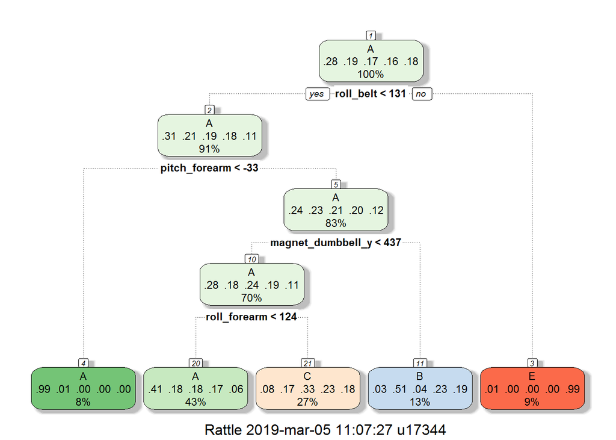

```r
abc1 <- train(classe~.,data = traindata4, method = "rpart")
fancyRpartPlot(abc1$finalModel)
```

```r
def1 <- predict(abc1,newdata = testdata4)
CM <- confusionMatrix(testdata4$classe,def1)
CM
```

```
## Confusion Matrix and Statistics
##
##           Reference
## Prediction    A    B    C    D    E
##          A 1530   35  105    0    4
##          B  486  379  274    0    0
##          C  493   31  502    0    0
##          D  452  164  348    0    0
##          E  168  145  302    0  467
##
## Overall Statistics
##
##                Accuracy : 0.489
##                  95% CI : (0.4762, 0.5019)
##     No Information Rate : 0.5317
##     P-Value [Acc > NIR] : 1
##
##                   Kappa : 0.3311
##  Mcnemar's Test P-Value : NA
##
## Statistics by Class:
##
##                      Class: A Class: B Class: C Class: D Class: E
## Sensitivity            0.4890   0.5027   0.3279       NA  0.99151
## Specificity            0.9478   0.8519   0.8797   0.8362  0.88641
## Pos Pred Value         0.9140   0.3327   0.4893       NA  0.43161
## Neg Pred Value         0.6203   0.9210   0.7882       NA  0.99917
## Prevalence             0.5317   0.1281   0.2602   0.0000  0.08003
## Detection Rate         0.2600   0.0644   0.0853   0.0000  0.07935
## Detection Prevalence   0.2845   0.1935   0.1743   0.1638  0.18386
## Balanced Accuracy      0.7184   0.6773   0.6038       NA  0.93896
```

```r
CM$overall[1]
```

```
##  Accuracy
## 0.4890399
```

We obtain an Accuracy of 0.49 with a Tree

### Random Forest

```r
abc2 <- train(classe~.,data = traindata4, method = "rf")
abc2$finalModel
```

```
##
## Call:
##  randomForest(x = x, y = y, mtry = param$mtry)
##                Type of random forest: classification
##                      Number of trees: 500
## No. of variables tried at each split: 27
##
##         OOB estimate of  error rate: 0.59%
## Confusion matrix:
##      A    B    C    D    E class.error
## A 3901    4    0    0    1 0.001280082
## B   20 2633    5    0    0 0.009405568
## C    0    9 2380    6    1 0.006677796
## D    0    0   20 2230    2 0.009769094
## E    0    1    5    7 2512 0.005148515
```

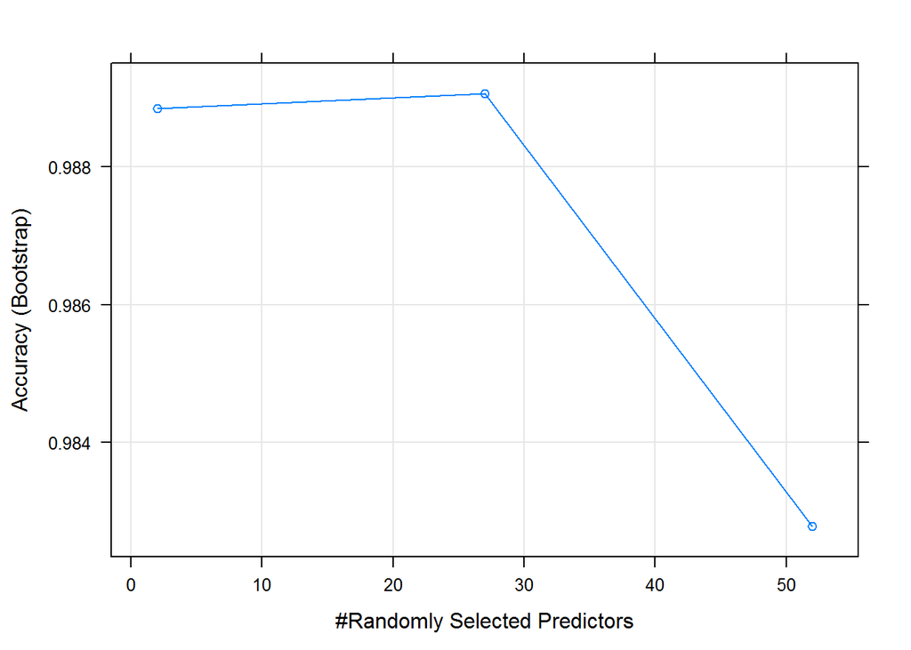

```r
plot(abc2)
```

```r
def2 <- predict(abc2,newdata = testdata4)
CM <- confusionMatrix(testdata4$classe,def2)
CM
```

```
## Confusion Matrix and Statistics
##
##           Reference
## Prediction    A    B    C    D    E
##          A 1674    0    0    0    0
##          B   12 1126    1    0    0
##          C    0    3 1019    4    0
##          D    0    1    4  958    1
##          E    0    1    2    3 1076
##
## Overall Statistics
##
##                Accuracy : 0.9946
##                  95% CI : (0.9923, 0.9963)
##     No Information Rate : 0.2865
##     P-Value [Acc > NIR] : < 2.2e-16
##
##                   Kappa : 0.9931
##  Mcnemar's Test P-Value : NA
##
## Statistics by Class:
##
##                      Class: A Class: B Class: C Class: D Class: E
## Sensitivity            0.9929   0.9956   0.9932   0.9927   0.9991
## Specificity            1.0000   0.9973   0.9986   0.9988   0.9988
## Pos Pred Value         1.0000   0.9886   0.9932   0.9938   0.9945
## Neg Pred Value         0.9972   0.9989   0.9986   0.9986   0.9998
## Prevalence             0.2865   0.1922   0.1743   0.1640   0.1830
## Detection Rate         0.2845   0.1913   0.1732   0.1628   0.1828
## Detection Prevalence   0.2845   0.1935   0.1743   0.1638   0.1839
## Balanced Accuracy      0.9964   0.9964   0.9959   0.9958   0.9989
```

```r
CM$overall[1]
```

```
##  Accuracy
## 0.9945624
```

We obtain an Accuracy of 0.99 with a Random Forest, with 27 Selected Predictors.

### Gradient Boosting

```r
abc3 <- train(classe~.,data = traindata4, method = "gbm")
abc3
```

```
## Stochastic Gradient Boosting
##
## 13737 samples
##    52 predictor
##     5 classes: 'A', 'B', 'C', 'D', 'E'
##
## No pre-processing
## Resampling: Bootstrapped (25 reps)
## Summary of sample sizes: 13737, 13737, 13737, 13737, 13737, 13737, ...
## Resampling results across tuning parameters:
##
##   interaction.depth  n.trees  Accuracy   Kappa
##   1                   50      0.7468666  0.6792932
##   1                  100      0.8147659  0.7656829
##   1                  150      0.8488348  0.8087921
##   2                   50      0.8514241  0.8118550
##   2                  100      0.9029867  0.8772721
##   2                  150      0.9282765  0.9092755
##   3                   50      0.8924972  0.8639553
##   3                  100      0.9380532  0.9216428
##   3                  150      0.9568182  0.9453871
##
## Tuning parameter 'shrinkage' was held constant at a value of 0.1
##
## Tuning parameter 'n.minobsinnode' was held constant at a value of 10
## Accuracy was used to select the optimal model using the largest value.
## The final values used for the model were n.trees = 150,
##  interaction.depth = 3, shrinkage = 0.1 and n.minobsinnode = 10.
```

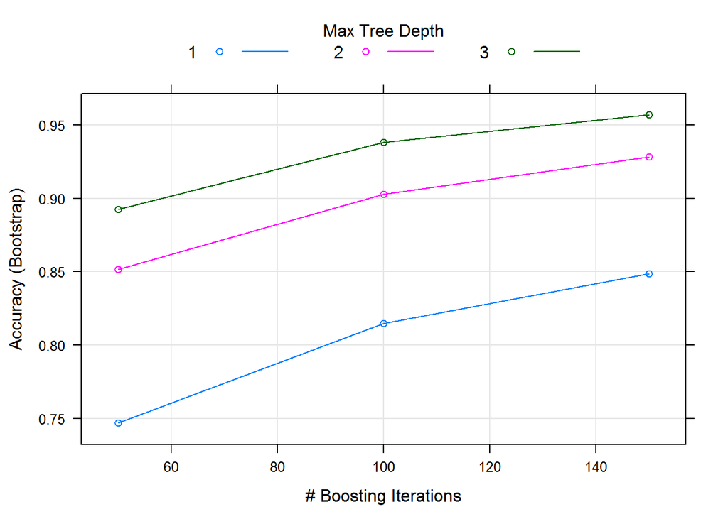

```r
plot(abc3)
```

```r
def3 <- predict(abc3,newdata = testdata4)
CM <- confusionMatrix(testdata4$classe,def3)
CM
```

```
## Confusion Matrix and Statistics
##
##           Reference
## Prediction    A    B    C    D    E
##          A 1655   12    2    4    1
##          B   37 1073   24    4    1
##          C    0   28  985   11    2
##          D    0    6   19  933    6
##          E    1   10   12   15 1044
##
## Overall Statistics
##
##                Accuracy : 0.9669
##                  95% CI : (0.962, 0.9713)
##     No Information Rate : 0.2877
##     P-Value [Acc > NIR] : < 2.2e-16
##
##                   Kappa : 0.9581
##  Mcnemar's Test P-Value : 1.722e-05
##
## Statistics by Class:
##
##                      Class: A Class: B Class: C Class: D Class: E
## Sensitivity            0.9776   0.9504   0.9453   0.9648   0.9905
## Specificity            0.9955   0.9861   0.9915   0.9937   0.9921
## Pos Pred Value         0.9886   0.9421   0.9600   0.9678   0.9649
## Neg Pred Value         0.9910   0.9882   0.9883   0.9931   0.9979
## Prevalence             0.2877   0.1918   0.1771   0.1643   0.1791
## Detection Rate         0.2812   0.1823   0.1674   0.1585   0.1774
## Detection Prevalence   0.2845   0.1935   0.1743   0.1638   0.1839
## Balanced Accuracy      0.9865   0.9683   0.9684   0.9793   0.9913
```

```r
CM$overall[1]
```

```
##  Accuracy
## 0.9668649
```

We obtain an Accuracy of 0.97

### Best Model

We conclude the best model is the Random Forest. We will apply it to the 20 new cases.

```r
def4 <- predict(abc2,newdata = testdata)
def4
```

```
##  [1] B A B A A E D B A A B C B A E E A B B B
## Levels: A B C D E
```